# SHRS Market Analysis — IPEDS Graduate Production (The Spigot)

SHRS MQE Capstone Team

2026-03-04

# 0 — Purpose & Context

This file answers a fundamental question: **how many graduates are being produced nationally to fill the replacement demand that BLS projects?**

BLS projections tell us how many job openings exist (the “holes”). IPEDS completions data tells us how many graduates are being produced to fill them (the “spigot”). By comparing the two, we can assess whether the labor market for each SHRS occupation is undersupplied, oversupplied, or in equilibrium.

# 1 — Setup

## 1.1 Packages

```r
# ── Core tidyverse ──
library(tidyverse)

# ── API access ──
# install.packages("educationdata")
# OR: devtools::install_github("UrbanInstitute/education-data-package-r")
library(educationdata)

# ── Display ──
library(scales)
library(kableExtra)
```

## 1.2 CIP Code Crosswalk

Each SHRS program maps to one or more 6-digit CIP codes. The Urban Institute API expects CIP codes as integers (no dots), so `51.0203` becomes `510203`.

We also include the SOC code link back to the BLS data from File 1/2 so downstream joins are trivial.

```r
# ═══════════════════════════════════════════════════════════════════════════
# CIP ↔ SHRS Program ↔ SOC Crosswalk
# ─────────────────────────────────────────────────────────────────────────
# Notes:
#   - CIP codes here use the 2020 CIP taxonomy (current as of IPEDS 2020-21+)
#   - Some programs map to multiple CIPs (e.g., SLP has its own code + a
#     combined SLP/AuD code). We include both to capture all completions.
#   - `cip_6digit` is the integer form for the API (no dots)
#   - `cip_display` is the human-readable form (with dots)
# ═══════════════════════════════════════════════════════════════════════════

cip_crosswalk <- tribble(
  ~shrs_program, ~shrs_dept, ~soc_code,  ~cip_6digit, ~cip_display, ~cip_title,

  # ── Communication Science & Disorders (CSD) ──
  "SLP",         "CSD",      "29-1127",  510203L,     "51.0203",    "Speech-Language Pathology/Pathologist",
  "SLP",         "CSD",      "29-1127",  510204L,     "51.0204",    "Audiology/Audiologist and SLP (Combined)",
  "AuD",         "CSD",      "29-1181",  510202L,     "51.0202",    "Audiology/Audiologist",
  "AuD",         "CSD",      "29-1181",  510204L,     "51.0204",    "Audiology/Audiologist and SLP (Combined)",

  # ── Sports Medicine & Nutrition (SMN) ──
  "DN",          "SMN",      "29-1031",  513101L,     "51.3101",    "Dietetics/Dietitian",
  "DN",          "SMN",      "29-1031",  513104L,     "51.3104",    "Dietitian Assistant",
  "AT",          "SMN",      "29-9091",  510913L,     "51.0913",    "Athletic Training/Trainer",
  "SS",          "SMN",      "29-1128",  260908L,     "26.0908",    "Exercise Physiology and Kinesiology",
  "SS",          "SMN",      "29-1128",  310505L,     "31.0505",    "Kinesiology and Exercise Science",

  # ── Rehabilitation Science & Technology (RST) ──
  "OTD",         "RST",      "29-1122",  512306L,     "51.2306",    "Occupational Therapy/Therapist",
  "DPT",         "RST",      "29-1123",  512308L,     "51.2308",    "Physical Therapy/Therapist",

  # ── Physician Assistant Studies (PAS) ──
  "PAS",         "PAS",      "29-1071",  510912L,     "51.0912",    "Physician Assistant",

  # ── Health Information Management (HIM) ──
  "HIM",         "HIM",      "29-9021",  510706L,     "51.0706",    "Health Information/Medical Records Administration",
  "HIM",         "HIM",      "29-9021",  510707L,     "51.0707",    "Health Information/Medical Records Technology/Technician"
)

# Unique CIP codes to pull from the API
target_cips <- unique(cip_crosswalk$cip_6digit)

cat("Target CIP codes:", paste(target_cips, collapse = ", "), "\n")
```

```
## Target CIP codes: 510203, 510204, 510202, 513101, 513104, 510913, 260908, 310505, 512306, 512308, 510912, 510706, 510707
```

```r
cat("SHRS programs covered:", paste(unique(cip_crosswalk$shrs_program), collapse = ", "), "\n")
```

```
## SHRS programs covered: SLP, AuD, DN, AT, SS, OTD, DPT, PAS, HIM
```

## 1.3 Award Level Reference

IPEDS award levels are coded as integers. We only care about degree-level awards for our programs (not certificates).

```r
# ═══════════════════════════════════════════════════════════════════════════
# IPEDS Award Level Codes
# ─────────────────────────────────────────────────────────────────────────
# These are the standard IPEDS award level codes used in the completions
# survey. The Urban Institute API uses the same codes.
#
# We focus on levels 5 (Bachelor's), 7 (Master's), 17 (Doctor's -
# Professional Practice), and 18 (Doctor's - Research/Scholarship).
# Level 17 is the relevant doctoral for clinical programs like AuD, DPT.
# Level 18 captures PhD/research doctorates.
# ═══════════════════════════════════════════════════════════════════════════

award_level_labels <- tribble(
  ~award_level, ~award_label,          ~degree_group,
  1L,           "< 1 year Certificate", "Certificate",
  2L,           "1-2 year Certificate",  "Certificate",
  3L,           "Associate's",           "Associate's",
  4L,           "2-4 year Certificate",  "Certificate",
  5L,           "Bachelor's",            "Bachelor's",
  6L,           "Postbacc Certificate",  "Certificate",
  7L,           "Master's",              "Master's",
  8L,           "Post-Master's Cert",    "Certificate",
  17L,          "Doctorate - Professional Practice", "Doctorate",
  18L,          "Doctorate - Research",  "Doctorate",
  19L,          "Doctorate - Other",     "Doctorate"
)

# The degree levels we care about for the spigot analysis
degree_levels <- c(5L, 7L, 17L, 18L, 19L)
degree_labels <- award_level_labels |> filter(award_level %in% degree_levels)
```

## 1.4 FIPS Code for Pennsylvania

```r
# Pennsylvania FIPS code for state-level filtering
PA_FIPS <- 42L

# Regional FIPS codes (PA + bordering states: OH, WV, MD, NY, NJ, DE, VA)
REGIONAL_FIPS <- c(
  42L,  # Pennsylvania
  39L,  # Ohio
  54L,  # West Virginia
  24L,  # Maryland
  36L,  # New York
  34L,  # New Jersey
  10L,  # Delaware
  51L   # Virginia
)

regional_fips_labels <- tribble(
  ~fips, ~state_abbr, ~state_name,
  42L,   "PA", "Pennsylvania",
  39L,   "OH", "Ohio",
  54L,   "WV", "West Virginia",
  24L,   "MD", "Maryland",
  36L,   "NY", "New York",
  34L,   "NJ", "New Jersey",
  10L,   "DE", "Delaware",
  51L,   "VA", "Virginia"
)
```

# 2 — Pull IPEDS Completions Data via API

We use the Urban Institute’s `educationdata` R package to pull completions by 6-digit CIP code. This hits the IPEDS completions-cip-6 endpoint, which returns institution-level award counts by CIP, award level, and year.

## 2.1 API Pull

```r
# ═══════════════════════════════════════════════════════════════════════════
# Pull completions data from the Urban Institute Education Data API
# ─────────────────────────────────────────────────────────────────────────
# Strategy:
#   - Pull one CIP × year combination at a time (most reliable)
#   - Request years 2012-2022 (reliable range for 6-digit CIP data)
#   - add_labels = FALSE (we apply our own labels downstream)
#
# The API returns one row per institution × year × CIP × award level ×
# race × sex. We aggregate up from there.
# ═══════════════════════════════════════════════════════════════════════════

# Year range — Urban Institute typically has data through 2022
YEAR_START <- 2012L
YEAR_END   <- 2022L

pull_one_cip_year <- function(cip_code, yr) {
  tryCatch({
    df <- get_education_data(
      level   = "college-university",
      source  = "ipeds",
      topic   = "completions-cip-6",
      filters = list(
        year           = yr,
        cipcode_6digit = cip_code
      ),
      add_labels = FALSE
    )
    return(df)
  }, error = function(e) {
    message("  ERROR: CIP ", cip_code, " / year ", yr, ": ", e$message)
    return(NULL)
  })
}

# Build grid of all CIP × year combinations
pull_grid <- expand.grid(
  cip  = target_cips,
  year = YEAR_START:YEAR_END,
  stringsAsFactors = FALSE
)

message("Pulling ", nrow(pull_grid), " CIP × year combinations ...")

# Pull one at a time — slow but reliable
raw_completions_list <- map2(
  pull_grid$cip, pull_grid$year,
  ~ {
    message("  CIP ", .x, " / ", .y)
    pull_one_cip_year(.x, .y)
  }
)

raw_completions <- bind_rows(compact(raw_completions_list))

cat("Total raw rows:", nrow(raw_completions), "\n")
```

```
## Total raw rows: 1517700
```

```r
if (nrow(raw_completions) > 0) {
  cat("Years covered:", paste(range(raw_completions$year), collapse = " to "), "\n")
  cat("CIP codes retrieved:", length(unique(raw_completions$cipcode_6digit)), "\n")
  cat("Columns:", paste(names(raw_completions), collapse = ", "), "\n")
} else {
  stop("API returned 0 rows. Check your internet connection and try again.")
}
```

```
## Years covered: 2012 to 2022
## CIP codes retrieved: 13
## Columns: unitid, year, fips, cipcode_6digit, award_level, majornum, race, sex, awards_6digit
```

## 2.2 Fallback: CSV Path (If API Is Unavailable)

If the API pull above fails or returns incomplete data, you can download the IPEDS completions data manually from NCES and load it here instead.

```r
# ═══════════════════════════════════════════════════════════════════════════
# FALLBACK: Manual CSV load
# ─────────────────────────────────────────────────────────────────────────
# 1. Go to https://nces.ed.gov/ipeds/use-the-data
# 2. Click "Download Survey Data" → "Complete Data Files"
# 3. Download the Completions (C20XX) files for each year you need
# 4. Place the extracted CSVs in your SHRS_Analysis folder
# 5. Update the path below and set eval=TRUE on this chunk
# ═══════════════════════════════════════════════════════════════════════════

# CSV_PATH <- file.path(path.expand("~"), "Documents", "SHRS_Analysis",
#                        "market_analysis", "ipeds")
#
# csv_files <- list.files(CSV_PATH, pattern = "c\\d{4}.*\\.csv$",
#                          full.names = TRUE, ignore.case = TRUE)
#
# raw_completions <- map(csv_files, read_csv, col_types = cols(.default = "c")) |>
#   bind_rows() |>
#   clean_names() |>
#   filter(cipcode %in% gsub("(\\d{2})(\\d{4})", "\\1.\\2", target_cips))
```

# 3 — Clean & Aggregate

## 3.1 Filter to Degree-Level Awards and Aggregate Nationally

```r
# ═══════════════════════════════════════════════════════════════════════════
# Cleaning pipeline
# ─────────────────────────────────────────────────────────────────────────
# Raw data is at institution × year × CIP × award_level × race × sex.
# We aggregate to get total completions at three levels:
#   1. National totals by CIP × award level × year
#   2. State-level totals by CIP × award level × year × FIPS
#   3. Institution-level totals by CIP × award level × year × unitid
# ═══════════════════════════════════════════════════════════════════════════

# Ensure cipcode_6digit is integer for joining
completions_clean <- raw_completions |>
  mutate(
    cipcode_6digit = as.integer(cipcode_6digit),
    award_level    = as.integer(award_level),
    awards         = as.numeric(awards_6digit),
    fips           = as.integer(fips)
  ) |>
  # Filter to degree-level awards only (drop certificates)
  filter(award_level %in% degree_levels) |>
  # Drop rows with 0 or NA awards
  filter(!is.na(awards), awards > 0) |>
  # Join to our crosswalk to get SHRS program labels
  inner_join(
    cip_crosswalk |> select(cip_6digit, shrs_program, shrs_dept, soc_code),
    by = c("cipcode_6digit" = "cip_6digit")
  ) |>
  # Join award level labels
  left_join(award_level_labels, by = "award_level")
```

## 3.2 Build Aggregation Tiers

```r
# ─── TIER 1: National totals by program × degree level × year ───────────
national_completions <- completions_clean |>
  group_by(year, shrs_program, shrs_dept, soc_code,
           award_level, award_label, degree_group) |>
  summarise(
    total_awards    = sum(awards, na.rm = TRUE),
    n_institutions  = n_distinct(unitid),
    .groups         = "drop"
  ) |>
  arrange(shrs_program, degree_group, year)

# ─── TIER 2: State-level totals ────────────────────────────────────────
state_completions <- completions_clean |>
  group_by(year, fips, shrs_program, shrs_dept, soc_code,
           award_level, award_label, degree_group) |>
  summarise(
    total_awards    = sum(awards, na.rm = TRUE),
    n_institutions  = n_distinct(unitid),
    .groups         = "drop"
  ) |>
  arrange(shrs_program, fips, year)

# ─── TIER 3: PA-specific and Regional ──────────────────────────────────
pa_completions <- state_completions |>
  filter(fips == PA_FIPS)

regional_completions <- state_completions |>
  filter(fips %in% REGIONAL_FIPS) |>
  left_join(regional_fips_labels, by = "fips")

# ─── TIER 4: Institution-level (for competitor analysis later) ──────────
institution_completions <- completions_clean |>
  group_by(year, unitid, fips, shrs_program, shrs_dept, soc_code,
           award_level, award_label, degree_group) |>
  summarise(
    total_awards = sum(awards, na.rm = TRUE),
    .groups      = "drop"
  )

cat("National completions rows:", nrow(national_completions), "\n")
```

```
## National completions rows: 99
```

```r
cat("State completions rows:", nrow(state_completions), "\n")
```

```
## State completions rows: 3116
```

```r
cat("PA completions rows:", nrow(pa_completions), "\n")
```

```
## PA completions rows: 99
```

```r
cat("Institution completions rows:", nrow(institution_completions), "\n")
```

```
## Institution completions rows: 14714
```

# 4 — National Completions Trends

## 4.1 Total Graduates Over Time by Program

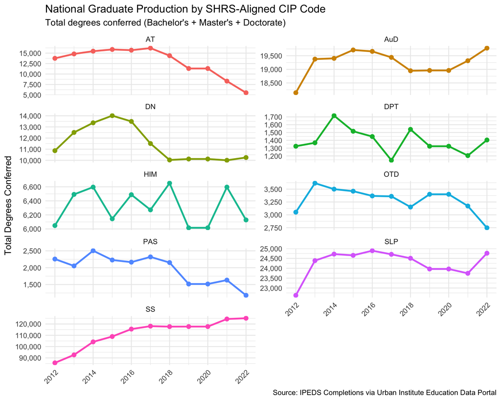

```r
# Aggregate across all degree levels for headline trend
national_total <- national_completions |>
  group_by(year, shrs_program, shrs_dept) |>
  summarise(total_awards = sum(total_awards), .groups = "drop")

national_total |>
  ggplot(aes(x = year, y = total_awards, color = shrs_program)) +
  geom_line(linewidth = 1.2) +
  geom_point(size = 2.5) +
  facet_wrap(~ shrs_program, scales = "free_y", ncol = 2) +
  scale_y_continuous(labels = comma) +
  scale_x_continuous(breaks = seq(YEAR_START, YEAR_END, 2)) +
  labs(
    title    = "National Graduate Production by SHRS-Aligned CIP Code",
    subtitle = "Total degrees conferred (Bachelor's + Master's + Doctorate)",
    caption  = "Source: IPEDS Completions via Urban Institute Education Data Portal",
    x = NULL, y = "Total Degrees Conferred"
  ) +
  theme_minimal(base_size = 13) +
  theme(legend.position = "none",
        axis.text.x = element_text(angle = 45, hjust = 1))
```

## 4.2 Completions by Degree Level

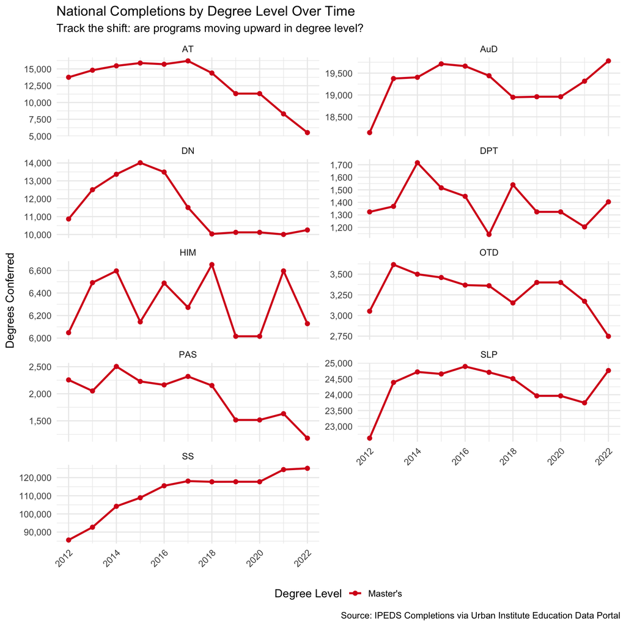

```r
national_completions |>
  ggplot(aes(x = year, y = total_awards, color = degree_group,
             linetype = degree_group)) +
  geom_line(linewidth = 1.1) +
  geom_point(size = 2) +
  facet_wrap(~ shrs_program, scales = "free_y", ncol = 2) +
  scale_y_continuous(labels = comma) +
  scale_x_continuous(breaks = seq(YEAR_START, YEAR_END, 2)) +
  scale_color_manual(values = c(
    "Bachelor's" = "#2c7bb6",
    "Master's"   = "#d7191c",
    "Doctorate"  = "#1a9641"
  )) +
  labs(
    title    = "National Completions by Degree Level Over Time",
    subtitle = "Track the shift: are programs moving upward in degree level?",
    caption  = "Source: IPEDS Completions via Urban Institute Education Data Portal",
    x = NULL, y = "Degrees Conferred", color = "Degree Level",
    linetype = "Degree Level"
  ) +
  theme_minimal(base_size = 13) +
  theme(legend.position = "bottom",
        axis.text.x = element_text(angle = 45, hjust = 1))
```

## 4.3 Degree Mix Shift (Proportion by Level)

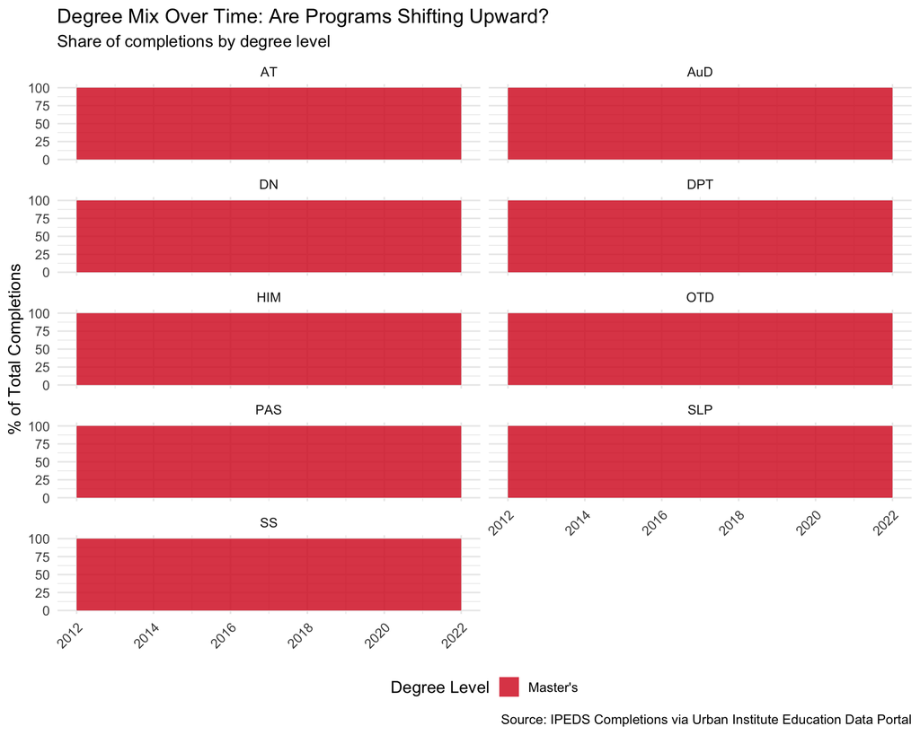

```r
national_completions |>
  group_by(year, shrs_program) |>
  mutate(pct = total_awards / sum(total_awards) * 100) |>
  ungroup() |>
  ggplot(aes(x = year, y = pct, fill = degree_group)) +
  geom_area(alpha = 0.8) +
  facet_wrap(~ shrs_program, ncol = 2) +
  scale_fill_manual(values = c(
    "Bachelor's" = "#2c7bb6",
    "Master's"   = "#d7191c",
    "Doctorate"  = "#1a9641"
  )) +
  scale_x_continuous(breaks = seq(YEAR_START, YEAR_END, 2)) +
  labs(
    title    = "Degree Mix Over Time: Are Programs Shifting Upward?",
    subtitle = "Share of completions by degree level",
    caption  = "Source: IPEDS Completions via Urban Institute Education Data Portal",
    x = NULL, y = "% of Total Completions", fill = "Degree Level"
  ) +
  theme_minimal(base_size = 13) +
  theme(legend.position = "bottom",
        axis.text.x = element_text(angle = 45, hjust = 1))
```

## 4.4 Growth Rates Summary

```r
# Calculate CAGR and absolute change over the full period
growth_summary <- national_total |>
  group_by(shrs_program) |>
  summarise(
    first_year     = min(year),
    last_year      = max(year),
    awards_start   = first(total_awards),
    awards_end     = last(total_awards),
    abs_change     = last(total_awards) - first(total_awards),
    pct_change     = round((last(total_awards) / first(total_awards) - 1) * 100, 1),
    n_years        = last_year - first_year,
    cagr           = round((((last(total_awards) / first(total_awards))^
                              (1 / n_years)) - 1) * 100, 2),
    .groups        = "drop"
  )

growth_summary |>
  select(
    Program        = shrs_program,
    `Start Year`   = first_year,
    `End Year`     = last_year,
    `Awards Start` = awards_start,
    `Awards End`   = awards_end,
    `Change`       = abs_change,
    `Growth (%)`   = pct_change,
    `CAGR (%)`     = cagr
  ) |>
  kable(format.args = list(big.mark = ",")) |>
  kable_styling(bootstrap_options = c("striped", "hover"), full_width = FALSE)
```

| Program | Start Year | End Year | Awards Start | Awards End | Change | Growth (%) | CAGR (%) |
| --- | --- | --- | --- | --- | --- | --- | --- |
| AT | 2,012 | 2,022 | 13,756 | 5,524 | -8,232 | -59.8 | -8.72 |
| AuD | 2,012 | 2,022 | 18,140 | 19,780 | 1,640 | 9.0 | 0.87 |
| DN | 2,012 | 2,022 | 10,868 | 10,252 | -616 | -5.7 | -0.58 |
| DPT | 2,012 | 2,022 | 1,324 | 1,404 | 80 | 6.0 | 0.59 |
| HIM | 2,012 | 2,022 | 6,048 | 6,128 | 80 | 1.3 | 0.13 |
| OTD | 2,012 | 2,022 | 3,052 | 2,748 | -304 | -10.0 | -1.04 |
| PAS | 2,012 | 2,022 | 2,256 | 1,180 | -1,076 | -47.7 | -6.28 |
| SLP | 2,012 | 2,022 | 22,628 | 24,764 | 2,136 | 9.4 | 0.91 |
| SS | 2,012 | 2,022 | 85,616 | 125,104 | 39,488 | 46.1 | 3.87 |

# 5 — Pennsylvania vs. National

## 5.1 PA Share of National Production

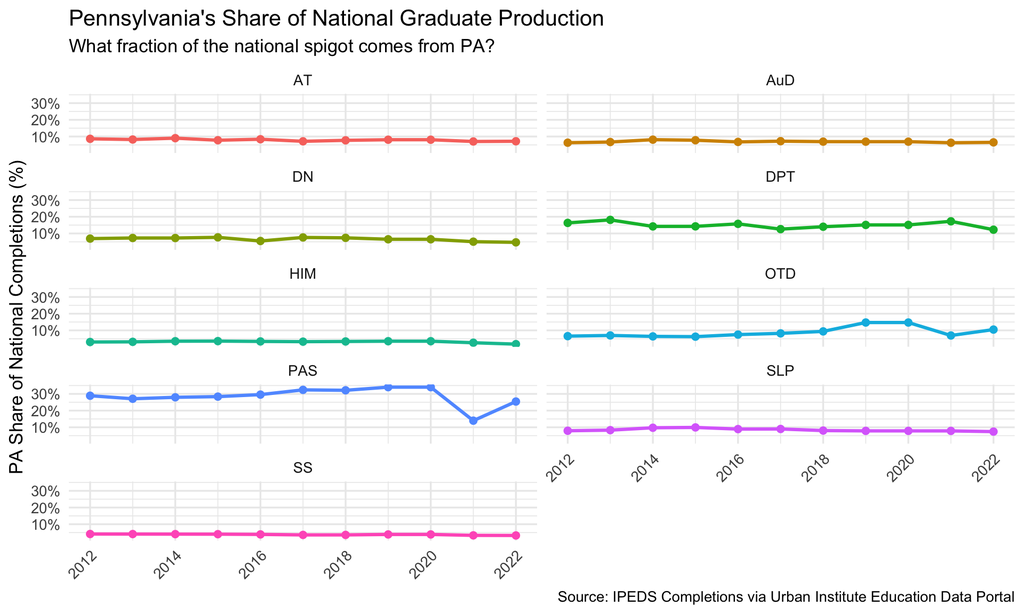

```r
pa_total <- pa_completions |>
  group_by(year, shrs_program) |>
  summarise(pa_awards = sum(total_awards), .groups = "drop")

pa_vs_national <- national_total |>
  left_join(pa_total, by = c("year", "shrs_program")) |>
  mutate(
    pa_awards = replace_na(pa_awards, 0),
    pa_share  = pa_awards / total_awards * 100
  )

pa_vs_national |>
  ggplot(aes(x = year, y = pa_share, color = shrs_program)) +
  geom_line(linewidth = 1.1) +
  geom_point(size = 2) +
  facet_wrap(~ shrs_program, ncol = 2) +
  scale_y_continuous(labels = function(x) paste0(x, "%")) +
  scale_x_continuous(breaks = seq(YEAR_START, YEAR_END, 2)) +
  labs(
    title    = "Pennsylvania's Share of National Graduate Production",
    subtitle = "What fraction of the national spigot comes from PA?",
    caption  = "Source: IPEDS Completions via Urban Institute Education Data Portal",
    x = NULL, y = "PA Share of National Completions (%)"
  ) +
  theme_minimal(base_size = 13) +
  theme(legend.position = "none",
        axis.text.x = element_text(angle = 45, hjust = 1))
```

## 5.2 Regional Production (PA + Bordering States)

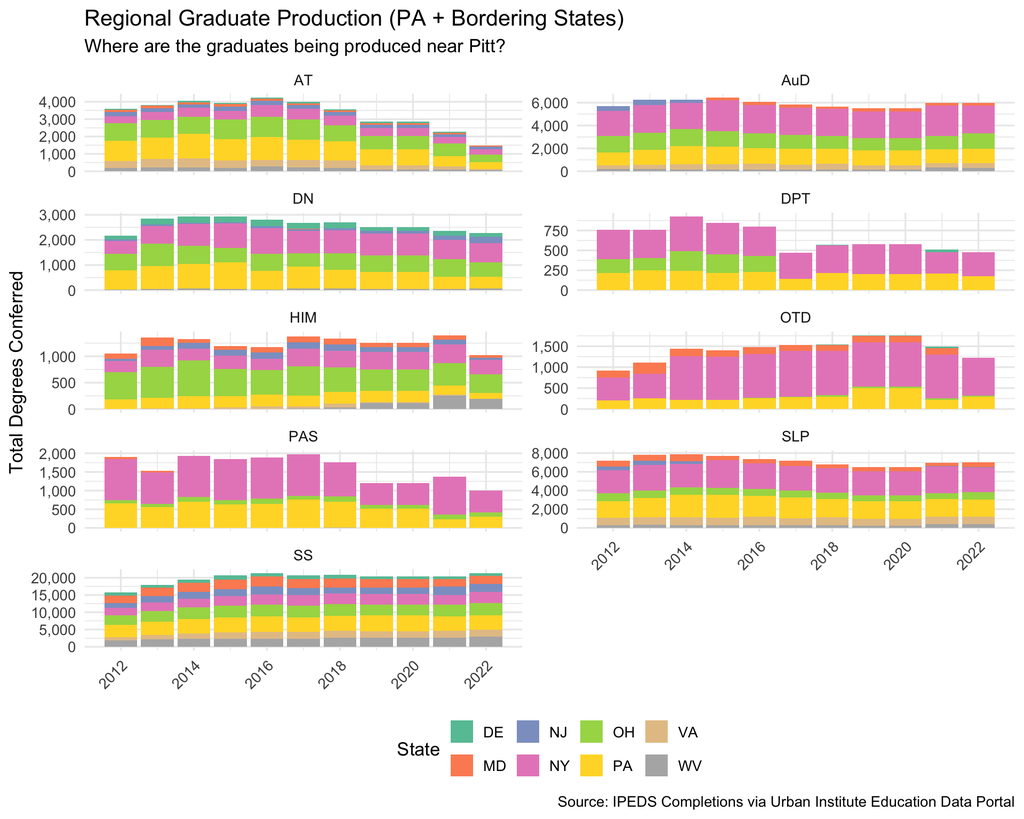

```r
regional_total <- regional_completions |>
  group_by(year, shrs_program, state_abbr) |>
  summarise(total_awards = sum(total_awards), .groups = "drop")

regional_total |>
  ggplot(aes(x = year, y = total_awards, fill = state_abbr)) +
  geom_col(position = "stack") +
  facet_wrap(~ shrs_program, scales = "free_y", ncol = 2) +
  scale_y_continuous(labels = comma) +
  scale_x_continuous(breaks = seq(YEAR_START, YEAR_END, 2)) +
  scale_fill_brewer(palette = "Set2") +
  labs(
    title    = "Regional Graduate Production (PA + Bordering States)",
    subtitle = "Where are the graduates being produced near Pitt?",
    caption  = "Source: IPEDS Completions via Urban Institute Education Data Portal",
    x = NULL, y = "Total Degrees Conferred", fill = "State"
  ) +
  theme_minimal(base_size = 13) +
  theme(legend.position = "bottom",
        axis.text.x = element_text(angle = 45, hjust = 1))
```

# 6 — Simple Forward Projection

Use a linear trend to project completions forward, giving Dave the “future numbers” he asked for. We project 5 years beyond the last observed year.

**Caveat**: These are simple trend extrapolations, not structural models. They assume recent historical patterns continue.

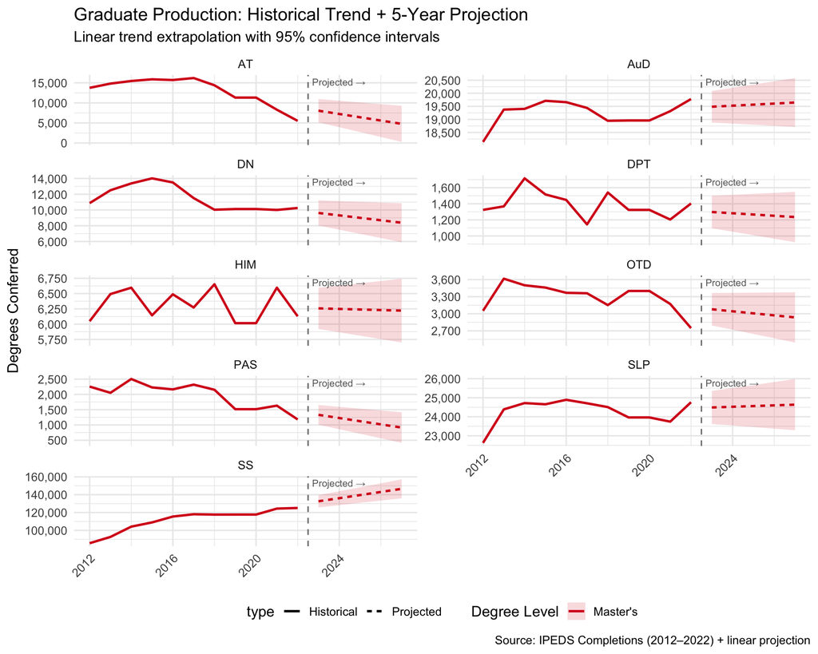

```r
# ═══════════════════════════════════════════════════════════════════════════
# Linear trend projection
# ─────────────────────────────────────────────────────────────────────────
# For each program × degree level, fit a simple linear model on the
# historical data and project forward 5 years.
# ═══════════════════════════════════════════════════════════════════════════

PROJ_YEARS <- 5
last_data_year <- max(national_completions$year, na.rm = TRUE)
future_years <- tibble(year = (last_data_year + 1):(last_data_year + PROJ_YEARS))

# Fit linear models per program × degree group
trend_models <- national_completions |>
  group_by(shrs_program, degree_group) |>
  summarise(
    data = list(tibble(year = year, total_awards = total_awards)),
    .groups = "drop"
  ) |>
  mutate(
    model   = map(data, ~ lm(total_awards ~ year, data = .x)),
    proj    = map(model, ~ predict(.x, newdata = future_years, se.fit = TRUE)),
    proj_df = map(proj, ~ tibble(
      year     = future_years$year,
      fit      = pmax(.x$fit, 0),           # Floor at 0 (can't have negative grads)
      se       = .x$se.fit,
      lower_95 = pmax(.x$fit - 1.96 * .x$se.fit, 0),
      upper_95 = pmax(.x$fit + 1.96 * .x$se.fit, 0)
    ))
  )

# Extract projections
projected_completions <- trend_models |>
  select(shrs_program, degree_group, proj_df) |>
  unnest(proj_df) |>
  mutate(type = "Projected")

# Combine historical + projected for plotting
historical_for_plot <- national_completions |>
  group_by(year, shrs_program, degree_group) |>
  summarise(fit = sum(total_awards), .groups = "drop") |>
  mutate(type = "Historical", se = NA_real_,
         lower_95 = NA_real_, upper_95 = NA_real_)

combined_trend <- bind_rows(historical_for_plot, projected_completions)

combined_trend |>
  ggplot(aes(x = year, y = fit, color = degree_group, linetype = type)) +
  geom_line(linewidth = 1) +
  geom_ribbon(
    data = combined_trend |> filter(type == "Projected"),
    aes(ymin = lower_95, ymax = upper_95, fill = degree_group),
    alpha = 0.15, linetype = 0
  ) +
  geom_vline(xintercept = last_data_year + 0.5, linetype = "dashed",
             color = "gray50") +
  annotate("text", x = last_data_year + 0.7, y = Inf, label = "Projected →",
           hjust = 0, vjust = 1.5, size = 3, color = "gray40") +
  facet_wrap(~ shrs_program, scales = "free_y", ncol = 2) +
  scale_y_continuous(labels = comma) +
  scale_color_manual(values = c(
    "Bachelor's" = "#2c7bb6",
    "Master's"   = "#d7191c",
    "Doctorate"  = "#1a9641"
  )) +
  scale_fill_manual(values = c(
    "Bachelor's" = "#2c7bb6",
    "Master's"   = "#d7191c",
    "Doctorate"  = "#1a9641"
  )) +
  labs(
    title    = "Graduate Production: Historical Trend + 5-Year Projection",
    subtitle = "Linear trend extrapolation with 95% confidence intervals",
    caption  = paste0("Source: IPEDS Completions (", YEAR_START, "–",
                      last_data_year, ") + linear projection"),
    x = NULL, y = "Degrees Conferred", color = "Degree Level",
    fill = "Degree Level"
  ) +
  theme_minimal(base_size = 13) +
  theme(legend.position = "bottom",
        axis.text.x = element_text(angle = 45, hjust = 1))
```

## 6.1 Projected Numbers Table

```r
projected_completions |>
  mutate(
    fit      = round(fit),
    lower_95 = round(lower_95),
    upper_95 = round(upper_95)
  ) |>
  select(
    Program        = shrs_program,
    `Degree Level` = degree_group,
    Year           = year,
    `Projected`    = fit,
    `Lower 95% CI` = lower_95,
    `Upper 95% CI` = upper_95
  ) |>
  kable(format.args = list(big.mark = ",")) |>
  kable_styling(bootstrap_options = c("striped", "hover"), full_width = FALSE) |>
  scroll_box(height = "400px")
```

| Program | Degree Level | Year | Projected | Lower 95% CI | Upper 95% CI |
| --- | --- | --- | --- | --- | --- |
| AT | Master’s | 2,023 | 8,060 | 5,148 | 10,972 |
| AT | Master’s | 2,024 | 7,242 | 3,944 | 10,540 |
| AT | Master’s | 2,025 | 6,424 | 2,730 | 10,117 |
| AT | Master’s | 2,026 | 5,605 | 1,510 | 9,701 |
| AT | Master’s | 2,027 | 4,787 | 284 | 9,290 |
| AuD | Master’s | 2,023 | 19,486 | 18,880 | 20,092 |
| AuD | Master’s | 2,024 | 19,526 | 18,840 | 20,212 |
| AuD | Master’s | 2,025 | 19,566 | 18,797 | 20,334 |
| AuD | Master’s | 2,026 | 19,606 | 18,754 | 20,458 |
| AuD | Master’s | 2,027 | 19,646 | 18,709 | 20,583 |
| DN | Master’s | 2,023 | 9,622 | 8,020 | 11,224 |
| DN | Master’s | 2,024 | 9,312 | 7,498 | 11,126 |
| DN | Master’s | 2,025 | 9,002 | 6,970 | 11,034 |
| DN | Master’s | 2,026 | 8,693 | 6,439 | 10,946 |
| DN | Master’s | 2,027 | 8,383 | 5,905 | 10,860 |
| DPT | Master’s | 2,023 | 1,298 | 1,095 | 1,501 |
| DPT | Master’s | 2,024 | 1,282 | 1,053 | 1,512 |
| DPT | Master’s | 2,025 | 1,267 | 1,010 | 1,524 |
| DPT | Master’s | 2,026 | 1,251 | 966 | 1,536 |
| DPT | Master’s | 2,027 | 1,235 | 922 | 1,548 |
| HIM | Master’s | 2,023 | 6,258 | 5,920 | 6,596 |
| HIM | Master’s | 2,024 | 6,249 | 5,866 | 6,631 |
| HIM | Master’s | 2,025 | 6,240 | 5,811 | 6,668 |
| HIM | Master’s | 2,026 | 6,230 | 5,755 | 6,706 |
| HIM | Master’s | 2,027 | 6,221 | 5,699 | 6,744 |
| OTD | Master’s | 2,023 | 3,079 | 2,793 | 3,365 |
| OTD | Master’s | 2,024 | 3,043 | 2,720 | 3,367 |
| OTD | Master’s | 2,025 | 3,007 | 2,645 | 3,370 |
| OTD | Master’s | 2,026 | 2,972 | 2,570 | 3,374 |
| OTD | Master’s | 2,027 | 2,936 | 2,494 | 3,378 |
| PAS | Master’s | 2,023 | 1,331 | 1,007 | 1,655 |
| PAS | Master’s | 2,024 | 1,227 | 860 | 1,594 |
| PAS | Master’s | 2,025 | 1,123 | 712 | 1,534 |
| PAS | Master’s | 2,026 | 1,019 | 563 | 1,474 |
| PAS | Master’s | 2,027 | 915 | 414 | 1,416 |
| SLP | Master’s | 2,023 | 24,489 | 23,617 | 25,360 |
| SLP | Master’s | 2,024 | 24,526 | 23,539 | 25,513 |
| SLP | Master’s | 2,025 | 24,563 | 23,457 | 25,668 |
| SLP | Master’s | 2,026 | 24,600 | 23,374 | 25,825 |
| SLP | Master’s | 2,027 | 24,637 | 23,289 | 25,984 |
| SS | Master’s | 2,023 | 132,586 | 125,704 | 139,468 |
| SS | Master’s | 2,024 | 136,083 | 128,289 | 143,878 |
| SS | Master’s | 2,025 | 139,581 | 130,852 | 148,310 |
| SS | Master’s | 2,026 | 143,079 | 133,399 | 152,759 |
| SS | Master’s | 2,027 | 146,577 | 135,934 | 157,219 |

# 7 — Spigot vs. Demand: Supply-Demand Gap

This is the synthesis: compare annual graduate production (the spigot) to BLS-projected annual openings (the holes).

**To use this section, you must first run `market_01_data_prep.Rmd` and `market_02_analysis.Rmd`** so that the `separations` object is available. If running standalone, we provide the BLS numbers inline.

```r
# ═══════════════════════════════════════════════════════════════════════════
# BLS Annual Openings (from market_02_analysis.Rmd separations table)
# ─────────────────────────────────────────────────────────────────────────
# If the separations object is not in memory, define the values manually
# from your latest BLS projection cycle (2024–2034).
# Annual openings are in thousands in the BLS data.
# ═══════════════════════════════════════════════════════════════════════════

# Try to use the separations object if available; otherwise define manually
if (!exists("separations")) {
  message("NOTE: 'separations' not in memory. Using manual BLS values.")
  message("Update these when you have the latest projection numbers.")

  bls_openings <- tribble(
    ~shrs_program, ~soc_code,   ~annual_openings_thousands,
    "SLP",         "29-1127",   15.1,
    "AuD",         "29-1181",   1.0,
    "DN",          "29-1031",   9.1,
    "AT",          "29-9091",   6.3,
    "SS",          "29-1128",   1.8,
    "OTD",         "29-1122",   10.4,
    "DPT",         "29-1123",   13.9,
    "PAS",         "29-1071",   12.8,
    "HIM",         "29-9021",   10.6
  ) |>
    mutate(annual_openings = annual_openings_thousands * 1000)

} else {
  bls_openings <- separations |>
    select(shrs_program, soc_code, annual_openings) |>
    mutate(annual_openings = annual_openings * 1000) # Convert from thousands
}

# Latest-year completions as the current "spigot" output
latest_spigot <- national_total |>
  filter(year == max(year)) |>
  select(shrs_program, annual_graduates = total_awards, spigot_year = year)

# Join and compute gap
supply_demand <- bls_openings |>
  left_join(latest_spigot, by = "shrs_program") |>
  mutate(
    gap              = annual_graduates - annual_openings,
    gap_ratio        = round(annual_graduates / annual_openings, 2),
    gap_signal       = case_when(
      gap_ratio >= 1.5 ~ "Oversupplied",
      gap_ratio >= 1.0 ~ "Balanced/Slight Surplus",
      gap_ratio >= 0.7 ~ "Tight Market",
      TRUE             ~ "Undersupplied"
    )
  )

supply_demand |>
  select(
    Program              = shrs_program,
    `BLS Annual Openings` = annual_openings,
    `Annual Graduates`    = annual_graduates,
    `Gap (Grads - Jobs)`  = gap,
    `Supply/Demand Ratio` = gap_ratio,
    Signal               = gap_signal
  ) |>
  kable(format.args = list(big.mark = ",")) |>
  kable_styling(bootstrap_options = c("striped", "hover"), full_width = FALSE)
```

| Program | BLS Annual Openings | Annual Graduates | Gap (Grads - Jobs) | Supply/Demand Ratio | Signal |
| --- | --- | --- | --- | --- | --- |
| SLP | 15,100 | 24,764 | 9,664 | 1.64 | Oversupplied |
| AuD | 1,000 | 19,780 | 18,780 | 19.78 | Oversupplied |
| DN | 9,100 | 10,252 | 1,152 | 1.13 | Balanced/Slight Surplus |
| AT | 6,300 | 5,524 | -776 | 0.88 | Tight Market |
| SS | 1,800 | 125,104 | 123,304 | 69.50 | Oversupplied |
| OTD | 10,400 | 2,748 | -7,652 | 0.26 | Undersupplied |
| DPT | 13,900 | 1,404 | -12,496 | 0.10 | Undersupplied |
| PAS | 12,800 | 1,180 | -11,620 | 0.09 | Undersupplied |
| HIM | 10,600 | 6,128 | -4,472 | 0.58 | Undersupplied |

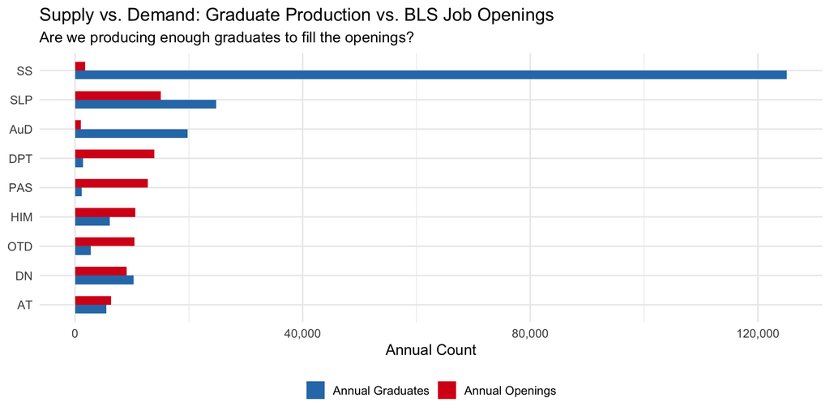

```r
supply_demand |>
  select(shrs_program, `Annual Openings` = annual_openings,
         `Annual Graduates` = annual_graduates) |>
  pivot_longer(-shrs_program, names_to = "measure", values_to = "count") |>
  ggplot(aes(x = reorder(shrs_program, count, max), y = count,
             fill = measure)) +
  geom_col(position = "dodge", width = 0.6) +
  coord_flip() +
  scale_y_continuous(labels = comma) +
  scale_fill_manual(values = c("Annual Openings" = "#d7191c",
                                "Annual Graduates" = "#2c7bb6")) +
  labs(
    title    = "Supply vs. Demand: Graduate Production vs. BLS Job Openings",
    subtitle = "Are we producing enough graduates to fill the openings?",
    x = NULL, y = "Annual Count", fill = NULL
  ) +
  theme_minimal(base_size = 13) +
  theme(legend.position = "bottom")
```

# 8 — Output Registry

All modular outputs from this file, ready for downstream analysis.

```r
# ═══════════════════════════════════════════════════════════════════════════
# OUTPUT REGISTRY
# ─────────────────────────────────────────────────────────────────────────
# Every object below is available for use in downstream Rmd files.
# Source this file with:
#   source(knitr::purl("ipeds_01_completions_spigot.Rmd",
#                       output = tempfile(), quiet = TRUE))
#
# Key objects:
# ─────────────────────────────────────────────────────────────────────────
#   CROSSWALKS & REFERENCE:
#     cip_crosswalk              CIP ↔ SHRS program ↔ SOC mapping
#     award_level_labels         IPEDS award level code → label
#     regional_fips_labels       FIPS → state abbreviation
#
#   RAW / CLEANED DATA:
#     raw_completions            Raw API pull (institution-level)
#     completions_clean          Cleaned + joined to crosswalk
#
#   AGGREGATED DATA (4 tiers):
#     national_completions       National totals by program × degree × year
#     state_completions          State-level totals
#     pa_completions             Pennsylvania only
#     regional_completions       PA + bordering states
#     institution_completions    Institution-level (for competitor analysis)
#
#   ANALYSIS OUTPUTS:
#     national_total             National totals (all degree levels combined)
#     growth_summary             CAGR and growth rates by program
#     pa_vs_national             PA share of national production
#     projected_completions      5-year linear projections by degree level
#     supply_demand              Spigot vs BLS openings gap analysis
#
#   CONSTANTS:
#     PA_FIPS                    Pennsylvania FIPS code (42)
#     REGIONAL_FIPS              PA + bordering state FIPS codes
#     target_cips                CIP codes we track
#     YEAR_START / YEAR_END      Data range
# ═══════════════════════════════════════════════════════════════════════════

cat("\n═══ IPEDS SPIGOT ANALYSIS: OUTPUT REGISTRY ═══\n")
```

```
##
## ═══ IPEDS SPIGOT ANALYSIS: OUTPUT REGISTRY ═══
```

```r
cat("National completions:", nrow(national_completions), "rows\n")
```

```
## National completions: 99 rows
```

```r
cat("State completions:", nrow(state_completions), "rows\n")
```

```
## State completions: 3116 rows
```

```r
cat("PA completions:", nrow(pa_completions), "rows\n")
```

```
## PA completions: 99 rows
```

```r
cat("Regional completions:", nrow(regional_completions), "rows\n")
```

```
## Regional completions: 566 rows
```

```r
cat("Institution completions:", nrow(institution_completions), "rows\n")
```

```
## Institution completions: 14714 rows
```

```r
cat("Projected completions:", nrow(projected_completions), "rows\n")
```

```
## Projected completions: 45 rows
```

```r
cat("Supply-demand gap:", nrow(supply_demand), "rows\n")
```

```
## Supply-demand gap: 9 rows
```

```r
cat("Years:", YEAR_START, "to", YEAR_END, "+ 5yr projection\n")
```

```
## Years: 2012 to 2022 + 5yr projection
```

```r
cat("═══════════════════════════════════════════════\n")
```

```
## ═══════════════════════════════════════════════
```

# Appendix: Data Sources & Methodology

**Data Source:**

- IPEDS Completions by 6-digit CIP code, accessed via the Urban Institute Education Data Portal API (`educationdata` R package)
- Award levels: Bachelor’s (5), Master’s (7), Doctorate — Professional Practice (17), Doctorate — Research (18), Doctorate — Other (19)

**CIP Code Mappings:**

| SHRS Program | CIP Code(s) | CIP Title |
| --- | --- | --- |
| SLP | 51.0203, 51.0204 | Speech-Language Pathology; Combined SLP/AuD |
| AuD | 51.0202, 51.0204 | Audiology; Combined SLP/AuD |
| DN | 51.3101, 51.3104 | Dietetics/Dietitian; Dietitian Assistant |
| AT | 51.0913 | Athletic Training/Trainer |
| SS | 26.0908, 31.0505 | Exercise Physiology; Kinesiology & Exercise Science |
| OTD | 51.2306 | Occupational Therapy/Therapist |
| DPT | 51.2308 | Physical Therapy/Therapist |
| PAS | 51.0912 | Physician Assistant |
| HIM | 51.0706, 51.0707 | Health Info/Medical Records Admin; Health Info Tech |

**Projection Methodology:**

- Simple linear trend (`lm(total_awards ~ year)`) per program × degree level
- 95% confidence intervals from `predict(..., se.fit = TRUE)`
- Projections floored at 0 (cannot produce negative graduates)
- This is a simple extrapolation, not a structural model

**Supply-Demand Gap:**

- “Spigot” = latest year IPEDS completions (annual graduates produced)
- “Holes” = BLS annual openings from the 2024–2034 projection cycle
- Gap ratio = annual graduates / annual openings
- Ratio > 1.0 suggests supply may exceed demand; < 1.0 suggests shortage

**Known Limitations:**

1. Urban Institute API data may lag IPEDS by 1–2 years
2. CIP 51.0204 (combined SLP/AuD) counts toward both SLP and AuD — this creates some double-counting. Adjust if needed for precision.
3. IPEDS counts degrees, not individuals entering the workforce (some graduates leave the state, change fields, or pursue further education)
4. BLS openings are national; PA-specific demand requires state projections (see projectionscentral.org for state-level BLS data)
5. Kinesiology/Exercise Science (CIP 31.0505) is a broad field — not all graduates become Exercise Physiologists